# Load Libraries

```r
library(dplyr)
library(tidyverse)
library(corrplot)
library(caret)
library(scales)
library(gridExtra)
library(maptools)
library(raster)
library(rgdal)
library(ggmap)
library(forcats)
library(reshape2)
```

# Load Data

```r
dt1 <- read.csv("russia_losses_equipment_correction.csv")
dt2 <- read.csv("russia_losses_equipment.csv")
dt3 <- read.csv("russia_losses_personnel.csv")
```

# Data Cleaning

- check for NA
- replace missing values
- Change the format of date in dt2, dt3
- Merge both datasets by date
- remove personnel. column
- column ‘vehicles and fuel tanks’ that can be merged with columns fuel.tank and military.auto
- helicopter and aircraft can be merged into ‘air_vehicles’

```r
any(is.na(dt1))
```

```
## [1] FALSE
```

```r
any(is.na(dt2))
```

```
## [1] TRUE
```

```r
any(is.na(dt3))
```

```
## [1] TRUE
```

```r
skimr::skim(dt1)
```

Data summary

| Name | dt1 |
| --- | --- |
| Number of rows | 1 |
| Number of columns | 6 |
| _______________________ |  |
| Column type frequency: |  |
| character | 1 |
| numeric | 5 |
| ________________________ |  |
| Group variables | None |

**Variable type: character**

| skim_variable | n_missing | complete_rate | min | max | empty | n_unique | whitespace |
| --- | --- | --- | --- | --- | --- | --- | --- |
| date | 0 | 1 | 10 | 10 | 0 | 1 | 0 |

**Variable type: numeric**

| skim_variable | n_missing | complete_rate | mean | sd | p0 | p25 | p50 | p75 | p100 | hist |
| --- | --- | --- | --- | --- | --- | --- | --- | --- | --- | --- |
| day | 0 | 1 | 231 | NA | 231 | 231 | 231 | 231 | 231 | ▁▁▇▁▁ |
| APC | 0 | 1 | -25 | NA | -25 | -25 | -25 | -25 | -25 | ▁▁▇▁▁ |
| field.artillery | 0 | 1 | 32 | NA | 32 | 32 | 32 | 32 | 32 | ▁▁▇▁▁ |
| drone | 0 | 1 | 20 | NA | 20 | 20 | 20 | 20 | 20 | ▁▁▇▁▁ |
| naval.ship | 0 | 1 | 1 | NA | 1 | 1 | 1 | 1 | 1 | ▁▁▇▁▁ |

```r
skimr::skim(dt2)
```

Data summary

| Name | dt2 |
| --- | --- |
| Number of rows | 256 |
| Number of columns | 18 |
| _______________________ |  |
| Column type frequency: |  |
| character | 2 |
| numeric | 16 |
| ________________________ |  |
| Group variables | None |

**Variable type: character**

| skim_variable | n_missing | complete_rate | min | max | empty | n_unique | whitespace |
| --- | --- | --- | --- | --- | --- | --- | --- |
| date | 0 | 1 | 10 | 10 | 0 | 256 | 0 |
| greatest.losses.direction | 0 | 1 | 0 | 43 | 76 | 59 | 0 |

**Variable type: numeric**

| skim_variable | n_missing | complete_rate | mean | sd | p0 | p25 | p50 | p75 | p100 | hist |
| --- | --- | --- | --- | --- | --- | --- | --- | --- | --- | --- |
| day | 0 | 1.00 | 129.50 | 74.05 | 2 | 65.75 | 129.5 | 193.25 | 257 | ▇▇▇▇▇ |
| aircraft | 0 | 1.00 | 202.25 | 61.27 | 10 | 189.75 | 217.0 | 236.00 | 277 | ▁▁▂▇▆ |
| helicopter | 0 | 1.00 | 177.38 | 49.22 | 7 | 155.00 | 186.5 | 206.00 | 260 | ▁▁▃▇▅ |
| tank | 0 | 1.00 | 1528.38 | 703.94 | 80 | 1002.50 | 1583.0 | 2053.75 | 2771 | ▃▅▇▇▅ |
| APC | 0 | 1.00 | 3483.37 | 1309.44 | 516 | 2438.25 | 3740.5 | 4437.25 | 5630 | ▂▅▅▇▆ |
| field.artillery | 0 | 1.00 | 832.46 | 464.42 | 49 | 435.75 | 800.5 | 1149.50 | 1782 | ▆▆▇▅▃ |
| MRL | 0 | 1.00 | 226.14 | 97.12 | 4 | 151.00 | 246.0 | 294.00 | 391 | ▂▃▅▇▅ |
| military.auto | 191 | 0.25 | 1047.51 | 466.16 | 100 | 600.00 | 1178.0 | 1437.00 | 1701 | ▃▃▃▆▇ |
| fuel.tank | 191 | 0.25 | 69.32 | 7.55 | 60 | 60.00 | 73.0 | 76.00 | 76 | ▆▁▁▁▇ |
| drone | 0 | 1.00 | 613.51 | 402.39 | 0 | 231.25 | 653.5 | 864.75 | 1472 | ▆▃▇▃▂ |
| naval.ship | 0 | 1.00 | 12.12 | 4.30 | 2 | 8.00 | 15.0 | 15.00 | 16 | ▂▁▁▂▇ |
| anti.aircraft.warfare | 0 | 1.00 | 111.24 | 50.85 | 0 | 76.00 | 105.0 | 156.00 | 202 | ▂▅▇▃▅ |
| special.equipment | 19 | 0.93 | 76.41 | 42.74 | 10 | 42.00 | 66.0 | 114.00 | 157 | ▆▇▃▃▅ |
| mobile.SRBM.system | 220 | 0.14 | 3.94 | 0.33 | 2 | 4.00 | 4.0 | 4.00 | 4 | ▁▁▁▁▇ |
| vehicles.and.fuel.tanks | 65 | 0.75 | 3016.34 | 670.88 | 1796 | 2504.50 | 2960.0 | 3598.50 | 4199 | ▅▇▇▅▇ |
| cruise.missiles | 65 | 0.75 | 192.92 | 79.68 | 84 | 129.00 | 182.0 | 239.00 | 399 | ▇▇▅▂▂ |

```r
#Change date datatype
dt2$date <- as.Date(dt2$date, "%Y-%m-%d")
dt3$date <- as.Date(dt3$date, "%Y-%m-%d")

#Merge by inner join
dt <- merge(dt2, dt3, by = "date", all = TRUE)

#Combine columns

for (i in 1:nrow(dt))
  {
    if (is.na(dt$vehicles.and.fuel.tanks[i])==FALSE) next
      else {
         dt$vehicles.and.fuel.tanks[i] = dt$military.auto[i] + dt$fuel.tank[i]
          }
  }

for (i in 1:nrow(dt))
  {
   dt$air_vehicles[i] = dt$aircraft[i] + dt$helicopter[i]
  }

#Remove columns that are not useful
dt <- subset(dt, select= -c (personnel., military.auto, fuel.tank, helicopter,aircraft))

#Set NA to 0 in mobile SRBM system
dt$mobile.SRBM.system[is.na(dt$mobile.SRBM.system)] <- 0

#Replace NA with maxmimum in POW
dt$POW[is.na(dt$POW)] <- 496

# Replace any other NA present with 0
dt[is.na(dt)] <- 0
```

The column greatest.losses.direction contains Ukrainian cities that were hit. Here’s what I’ll do:

- Separate city names
- Generate latitude and longitude

```r
city <- unlist(strsplit(dt$greatest.losses.direction, ","))
city<- gsub(" ", "", city)
city<- unlist(strsplit(city, "and"))
location <- as.data.frame(table(city))
location$country <- "Ukraine"
class(location$city)
```

```
## [1] "factor"
```

```r
location$city <- as.character(location$city)
```

```r
#generating latitude and longitude
latlong <- geocode(location$city)
location <- cbind(location, latlong) %>% rename(long = lon)
write.csv(location, "location_Ukraine.csv", row.names = FALSE)
```

```r
head(location, 10)
```

```
##          city Freq country     long      lat
## 1    Avdiivka   21 Ukraine 37.74913 48.13660
## 2     Bakhmut   62 Ukraine 37.99804 48.59867
## 3     Donetsk   62 Ukraine 37.80285 48.01588
## 4       Izyum    8 Ukraine 37.26650 49.21214
## 5     Kharkiv    7 Ukraine 36.23038 49.99350
## 6  Kramatorsk   32 Ukraine 37.58435 48.73897
## 7   KryvyiRih   25 Ukraine 33.39178 47.91048
## 8   Kurakhove   14 Ukraine 37.29070 47.98658
## 9       Lyman   10 Ukraine 37.80500 48.98976
## 10   Mykolaiv    4 Ukraine 31.99458 46.97503
```

[figure not shown]

```r
map_ukr <- get_map(location = c(31.1656, 48.3794), source = "google",zoom =6, maptype = "terrain")
ggmap(map_ukr)+
  geom_polygon(data= location, aes(x=long, y = lat, group = `city`),
               fill='white', color='green', alpha = 0.4) +
  geom_point(data = location, aes(x = long, y = lat), color = 'red')
```

# Visualizations

1. Hit cities
2. Loss of air weapons
3. Loss of water weapons
4. Loss of field weapons
5. Loss of military: death + prisoners

```r
#Hit cities
Ukraine<-getData("GADM", country="UA", level=0)
Ukraine1<-getData("GADM", country="UA", level=1)
```

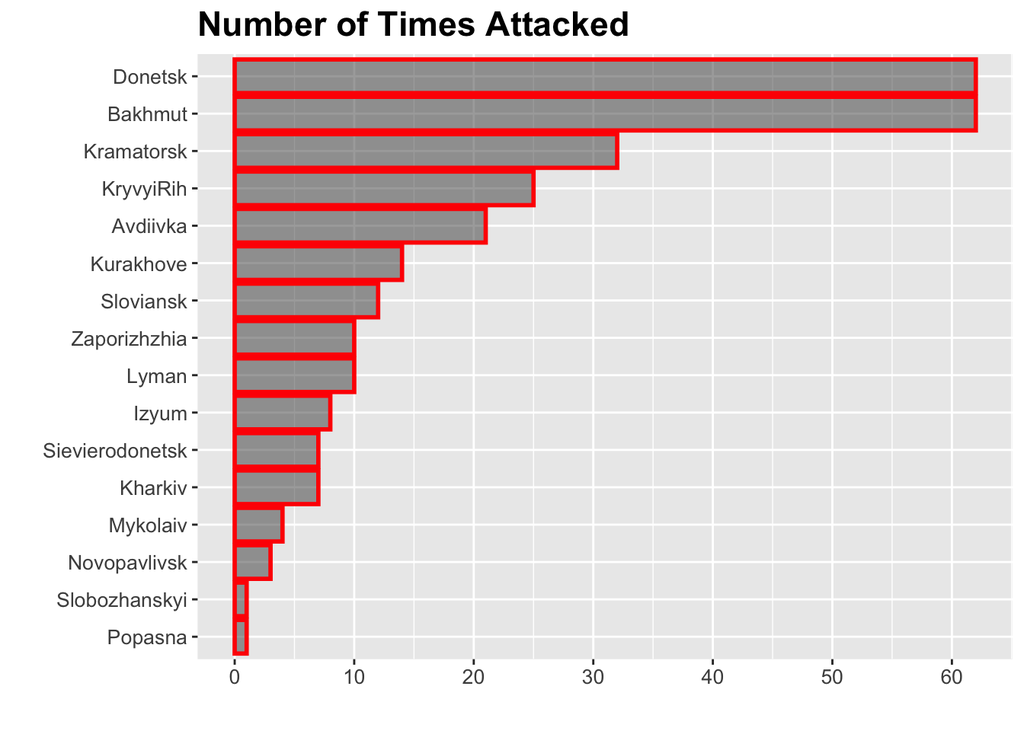

```r
ggplot(location, aes(Freq, reorder(city, Freq), alpha=0.1))+
  geom_col(size=1, col="red")+
    labs(title="Number of Times Attacked", x="", y="")+
    theme(axis.text.x = element_text(size=10),
          axis.text.y = element_text(size=10),
          title= element_text(size=14, face="bold"),
           legend.position = "none")+
    scale_x_continuous(breaks = seq(0, max(dt$special.equipment), by=10))
```

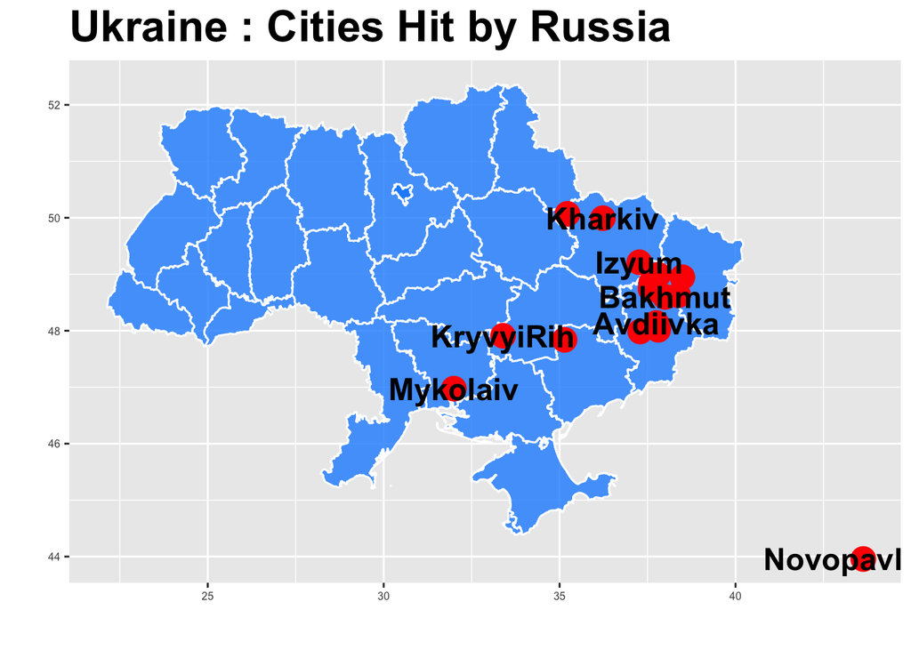

```r
plot <- ggplot()+
    geom_polygon(data=Ukraine1, aes(long, lat, group=group), color="white",fill="dodgerblue1", alpha=0.8)+
    geom_point(data=location, aes(long,lat), color="red", size=6)+
    geom_text(data=location, aes(label=city, x= long, y=lat), size=6, color="black", fontface="bold", check_overlap=TRUE)+
    labs(title="Ukraine : Cities Hit by Russia", x="", y="")+
    theme(axis.text.x = element_text(size=6),
          axis.text.y = element_text(size=6),
          title= element_text(size=20, face="bold"))
plot
```

## Loss of Equipment

### Air-based Eqipment Loss

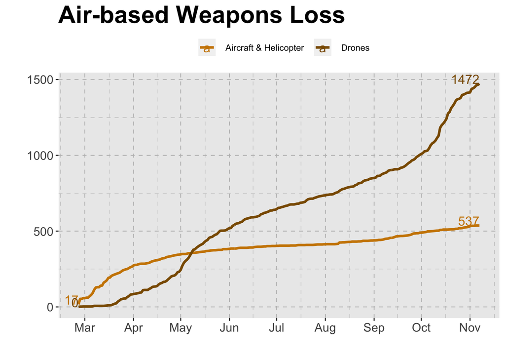

```r
#Air
melt_air <- dt %>% dplyr::select(c("air_vehicles", "drone", "date"))
melt_air <- melt(melt_air, id = "date")

ggplot(melt_air, aes(x = date, y = value, color = variable)) +
  geom_line(size=1.2)+
  scale_x_date(breaks='1 month', labels= date_format("%b"))+
  geom_text(data = subset(melt_air, date==c(min(dt$date),max(dt$date))), aes(label=value),hjust=1,vjust=0, size=4.5)+
  labs(title="Air-based Weapons Loss", x="Month", y = "Count", color=NULL)+
  theme(title= element_text(face="bold", hjust=4, size=20),
        axis.text.x = element_text(size=12),
        axis.text.y = element_text(size=12),
        legend.position = "top",
        panel.grid=element_line(size=0.4, color="gray", linetype=2))+
  scale_color_manual(values = c("orange3", "orange4"),
                     labels= c("Aircraft & Helicopter", "Drones"))
```

### Water-based Eqipment Loss

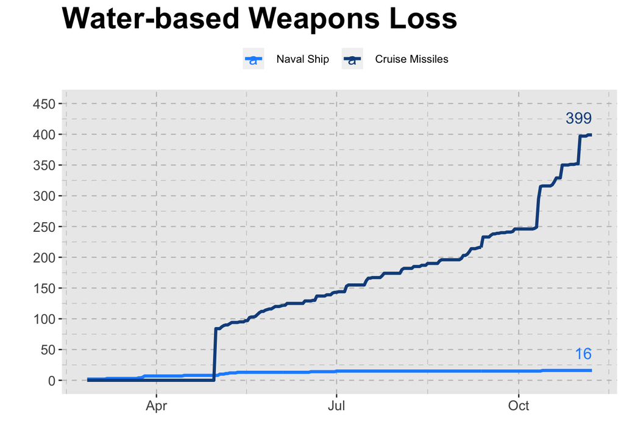

```r
# Water
melt_water <- dt %>% dplyr::select(c("naval.ship", "cruise.missiles", "date"))
melt_water <- melt(melt_water, id="date")

ggplot(melt_water, aes(x=date,y=value, color=variable))+
  geom_line(size=1.2)+
  scale_y_continuous( limits = c(0, 450), breaks= seq(0,450,by=50))+
  geom_text(data = subset(melt_water, date==max(dt$date)),
            aes(label=value,hjust=1,vjust=-1),
            size=4.5)+
  labs(title="Water-based Weapons Loss", x="Month", y = "Count", color=NULL)+
  theme(title= element_text(face="bold", hjust=4, size=20),
        axis.text.x = element_text(size=11),
        axis.text.y = element_text(size=11),
        legend.position = "top",
        panel.grid=element_line(size=0.4, color="gray", linetype=2))+
  scale_color_manual(values = c("dodgerblue1", "dodgerblue4"),
                     labels= c("Naval Ship", "Cruise Missiles"))
```

### Field-based Eqipment Loss

```r
# Field
library(viridis)
```

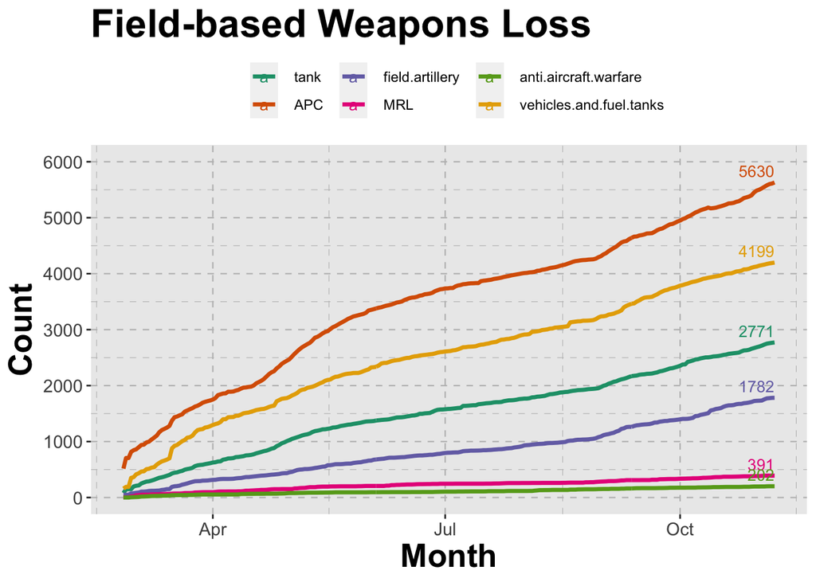

```r
melt_field<- dt %>% dplyr::select(c("tank", "APC", "field.artillery","MRL","anti.aircraft.warfare","vehicles.and.fuel.tanks","date"))
melt_field <- melt(melt_field, id="date")

ggplot(melt_field, aes(x=date,y=value, color=variable))+
  geom_line(size=1.2)+
  geom_text(data = subset(melt_field, date==max(dt$date)),
            aes(label=value,hjust=1,vjust=-0.5),
            size=3.5)+
  labs(title="Field-based Weapons Loss", x="Month", y = "Count", color=NULL)+
  scale_y_continuous( limits = c(0, 6000), breaks= seq(0,6000,by=1000))+
  theme(title= element_text(face="bold", hjust=0.5, size=20),
        axis.text.x = element_text(size=11),
        axis.text.y = element_text(size=11),
        legend.position = "top",
        panel.grid=element_line(size=0.4, color="gray", linetype=2))+
        scale_color_brewer(type= "qual", palette = "Dark2")
```

### Special Eqipment Loss

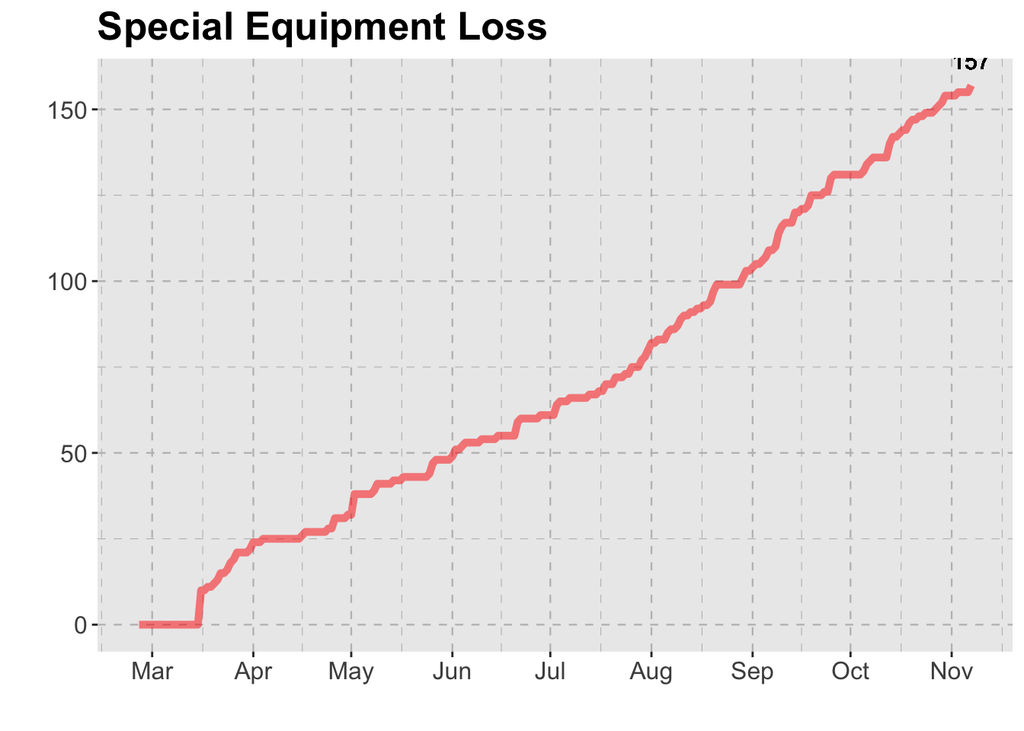

```r
ggplot(dt, aes(x= date,y= special.equipment)) +
geom_line(size=1.8, color="red", alpha=0.5)+
labs(title="Special Equipment Loss",x="",y="",color=NULL)+
geom_text(aes(x=max(`date`), y=max(`special.equipment`), label = max(`special.equipment`)), size=4, vjust=-1)+
theme(title= element_text(face="bold", hjust=0.5, size=16),
        axis.text.x = element_text(size=12),
        axis.text.y = element_text(size=12),
        legend.position = "bottom",
        legend.text = element_text(size=18),
        panel.grid=element_line(size=0.4, color="gray", linetype=2))+
        scale_color_brewer(type= "qual", palette = "Dark2")+
scale_x_date(date_breaks= "1 month", date_label = "%b")
```